# Week 6 Day 3 Homework

# Task 3.

Compute and visualise a bootstrap sampling distribution for the mean(lot_area) of the sold houses.

## Thoughts

Create a bootstrap re-sampling of the ames data since this is not the “sample. and calculate the mean of the lot.

## Discussion and code

```r
bootstrap_sample_creation <- function(.data, rep_num){
  .data %>%
  specify(response = lot_area) %>%
  generate(reps = rep_num, type = "bootstrap") %>%
  calculate(stat = "mean")
}
```

```r
reps <- 5000

bootstrap_sample <- ames %>%
  bootstrap_sample_creation(reps)
```

# Task 4.

Use your bootstrap distribution to calculate a 95% CI for mean(lot_area), and visualise it on the distribution

## Thoughts

Obtain the confidence intervals using the get_ci(), then apply this to the histogram of the bootstrap sample. The CI seems to apply cover the most of the theoretical mean of the overall population based on our sample set. The distribution of the theoretical mean is fairly normalised.

| lower_ci | upper_ci |
| --- | --- |
| 9886.618 | 10458.12 |

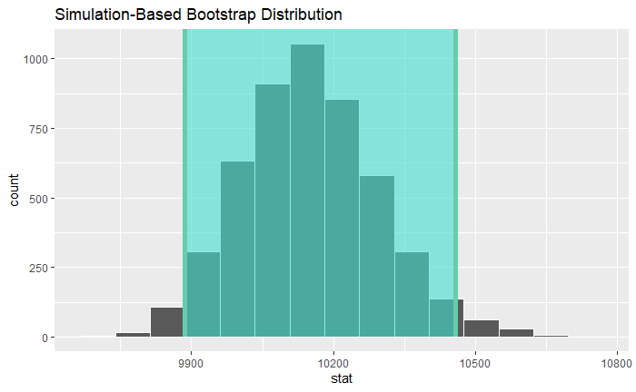

## Task 5.

You would like to know the mean(lot_area) of the sold houses with higher confidence. Calculate the 99% CI for this variable (you can re-use your bootstrap distribution from above). Is it narrower or broader than the 95% CI? Does that make sense?

## Thoughts

For more conidence in the mean we will need to enlarge the confidence interval width. Complete this similar to above but modify for 99%.

## Discussion and code

As expected, the width has increased to accomodate a large confidence.

| groups | lower_ci | upper_ci | width |
| --- | --- | --- | --- |
| CI_95 | 9886.618 | 10458.12 | 571.5016 |
| CI_99 | 9826.135 | 10566.86 | 740.7222 |

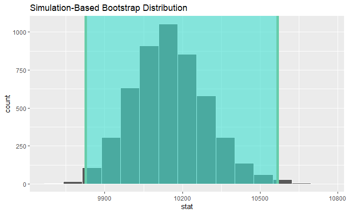

```r
bootstrap_sample %>%
  visualise(bins = 15) +
  shade_ci(endpoints = sample_ci_99)
```

## Thoughts

Generate the standard deviation of the bootstrap mean.

## Discussion and code

The point estimate for the sample generates is as shown below. This provides the standard error for the theoretical mean obtained.

| point_estimate | mean |
| --- | --- |
| 144.1017 | 10150.06 |

# 2 Extension

# Task 1.

Calculate a point estimate and 95% CI for the proportion of houses in the data built before 1920. Does the number of reps you use matter? [Investigate reps from 200 up to 50000, memory of your laptop permitting].

## Thoughts

Create a loop which generates a a variation in the “reps” from 200 to 50000. The data will need to be filtered first before applying to this.

## Discussion and code

[output not shown]

[output cut: 223 more lines]

```r
reps = seq(200, 50000, 100)

point_estimate_vector <- vector("numeric", length = length(reps))

##lapply()??

for (rep_loop in 1:length(reps)){

  point_estimate_vector[rep_loop] <- ames_before_1920 %>%
    boostrap_sample_creation(rep_num = rep_loop) %>%
    summarise(sd = sd(stat)) %>%
    pull(sd)

  #print(paste(rep_loop, point_estimate_vector[rep_loop]))

}

point_estimate_tibble = tibble(
  rep_number = reps,
  point_estimate = point_estimate_vector
)



# ames_before_1920 %>%
#     boostrap_sample_creation(rep_num = 200) %>%
#     summarise(sd = sd(stat)) %>%
#     pull(sd)
```

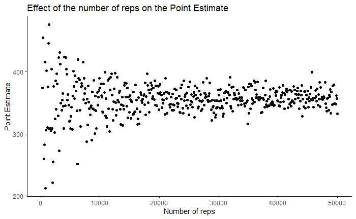

```r
point_estimate_tibble %>%
  ggplot(aes(x = rep_number, y = point_estimate)) +
  geom_point() +
  theme_classic() +
  labs(x = "Number of reps",
       y = "Point Estimate",
       title = "Effect of the number of reps on the Point Estimate")
```

From the plots of spread of the point estimate becomes smaller the greater the number of reps that are used.